# Moose Landcape Change Hypothesis Analysis

Tyler Muhly

04/15/2020

## Introduction

Here I document how I estimated landscape metrics to explore the moose ‘landscape change hypothesis’ (LCH). The moose LCH posits that recent moose population declines in parts of central British Columbia (BC) were related to large-scale changes to forest cover (i.e., landscape disturbance), caused by an extensive mountain pine beetle (MPB) infestation and subsequent forest harvest to salvage MPB killed forest stands. The LCH predicts a negative relationship between the amount of landscape disturbance and adult female moose survival. This relationship is indicative that processes related to landscape disturbance, i.e., reduced amount of security and thermal cover and increased amounts of negative interactions with humans (e.g., hunting mortality) due to higher road densities cause moose population declines. As a preliminary test of the LCH, here I use a mixed effects regression model to relate estimates of forest disturbance from MPB and forestry (cutblocks) to estimates of adult female moose survival in five study areas.

## Methods

### Population Data

Adult female moose survival rates were estimated annually from mortality data collected from the sampled animals. Survival was estimated for a biological year, i.e., April to April(?), not a calendar year. Thus, for example, a survival estimate for 2015 was calculated using mortality data collected from April 2014 to April 2015.

### Estimating Area of Cutblocks in Study Areas

I estimated the area of less than 9 year old forestry cutblocks and MPB disturbed stands in each study area. I estimated the area of cutblocks using the [consolidated cutblocks](https://catalogue.data.gov.bc.ca/dataset/harvested-areas-of-bc-consolidated-cutblocks-) dataset for BC. I intersected this data with the study area boundaries and then summarized the area cut by year from 2006 to 2018. I then calculated the area of cutblocks less than 9 years old for each study area year to align with adult female moose survival estimates for that year. For example, for survival estimates calculated for year 2015, I calculated the area cut from 2008 to 2015 as an estimate of area cut less than 9 years old. Thus, the assumption was the majority of area was cut early in a calendar year, during the period which survival estimates were calculated.

### Estimating Area of Mountain Pine Beetle Disturbed Stands in Study Areas

I estimated the area of forest stands disturbed by mountain pine beetle in each study area using data collected from [annual aerial surveys](https://www2.gov.bc.ca/gov/content/industry/forestry/managing-our-forest-resources/forest-health/aerial-overview-surveys/methods) by the government of BC. These data were accessible through an [FTP site](https://www.for.gov.bc.ca/ftp/HFP/external/!publish/Aerial_Overview/), and I downloaded annual datasets from 1999 to 2018. I summarized the area of moderately (11 to 29%), severely (30 to 49%) and very severely (>50%) disturbed forest stands for each year. Estimates cannot be added cumulatively each year, as damage to stands measured in previous years may be updated with new data from subsequent years. Thus, I ensured that spatially overlapping stands were updated using ArcGIS. I also deleted any areas that overlapped with cutblocks less than or equal to eight years old to avoid double-counting total disturbance where these types overlapped. I then calculated the area of MPB disturbed stands less than 9 years old for each study area year to align with adult female moose survival estimates for that year. MPB surveys were typically completed in July-August, thus, for example, for survival estimates calculated for year 2015, I calculated the area of MPB disturbed stands from 2008 to 2015 as an estimate of area of MPB stands less than 9 years old.

### Estimating Population Parameters

- currently using data provided in Doug’s spreadsheet
- dependent variables are currently:
  - annual adult female survival rate
    - total
    - hunting
    - wolf

**Table 1. Moose Population Parameter Estimates by Study Area and Year.**

| Study Area | Adult Female Survival Rate (all mortality factors) | Adult Female Survival Rate (hunting mortality only) | Adult Female Survival Rate (wolf mortality only) |
| --- | --- | --- | --- |
| Big Creek2015 | 0.923 | 0.970 | 0.953 |
| Big Creek2016 | 0.862 | 0.975 | 0.953 |
| Big Creek2017 | 0.897 | 0.974 | 0.949 |
| Big Creek2018 | 0.901 | 0.951 | 0.951 |
| Bonaparte2015 | 0.978 | NA | NA |
| Bonaparte2016 | 0.917 | 0.955 | NA |
| Bonaparte2017 | 0.938 | 0.985 | 0.969 |
| Bonaparte2018 | 0.982 | 0.982 | NA |
| Entiako2015 | 0.913 | NA | 0.959 |
| Entiako2016 | 0.818 | NA | 0.879 |
| Entiako2017 | 0.756 | NA | 0.828 |
| Entiako2018 | 0.818 | NA | 0.937 |
| John Prince Research Forest2016 | 0.923 | NA | 0.949 |
| John Prince Research Forest2017 | 0.949 | NA | 0.976 |
| John Prince Research Forest2018 | 0.950 | 0.975 | NA |
| Prince George South2015 | 0.933 | NA | NA |
| Prince George South2016 | 0.842 | 0.968 | 0.968 |
| Prince George South2017 | 0.946 | 0.974 | 0.972 |
| Prince George South2018 | 0.768 | NA | 0.873 |

### Mixed Effects Model of Relationship Between Adult Female Moose Survival and Landscape Disturbance

We wanted to test the effect of landscape disturbance on moose survival across the interior of BC (i.e., the ‘population-level’ effect), and we repeatedly sampled moose in specific landscapes (i.e., study area ‘subjects’) with different levels of disturbance (i.e., treatments). To correctly assess the population-level effect of disturbance, we needed to account for repeated sampling of subjects in our regression model. Thus, we used a mixed effects regression model that included a random effect intercept for each study area to account for the fact that each study area had unique disturbance levels, and an autocorrelation structure with a lag of 1 (AR1), which fits the model accounting for the fact that samples from the same study area are correlated with each other. These models were fit using the [nlme](https://cran.r-project.org/web/packages/nlme/nlme.pdf) pacakge in program R.

## Preliminary Results

Here I provide a preliminary description of the relationship between estimates of landscape disturbance and moose adult female survival. Entiako was typically the largest study area, at approximately 1,000,000 ha, and Bonaparte was typically the smallest study area, at approximately 320,000 ha (Table 2). The JPRF study area had typically the highest amount of less than 9 year old cutblocks. The Big Creek study area typically had the highest amount of less than 9 year old MPB disturbed forest stands.

**Table 2. Summary of Cutblock and Mountain Pine Beetle Disturbance Area by Study Area and Year.**

| Study Area | Year | Area (ha) | Area of Cutblocks Less Than 8 y.o. (ha) | Area of MPB Disturbed Stands Less Than 8 y.o. (ha) |
| --- | --- | --- | --- | --- |
| Big Creek | 2015 | 545,834 | 39,475 | 51,693 |
| Big Creek | 2016 | 553,616 | 35,378 | 49,284 |
| Big Creek | 2017 | 704,067 | 37,010 | 1,986 |
| Big Creek | 2018 | 681,246 | 33,396 | 3,072 |
| Bonaparte | 2015 | 304,819 | 43,263 | 48,743 |
| Bonaparte | 2016 | 302,766 | 41,757 | 637 |
| Bonaparte | 2017 | 329,259 | 39,651 | 0 |
| Bonaparte | 2018 | 356,691 | 39,720 | 0 |
| Entiako | 2015 | 1,001,269 | 16,586 | 2,193 |
| Entiako | 2016 | 1,155,045 | 24,168 | 22,366 |
| Entiako | 2017 | 932,118 | 18,702 | 225 |
| Entiako | 2018 | 798,654 | 15,893 | 0 |
| John Prince Research Forest | 2016 | 539,671 | 51,405 | 5,237 |
| John Prince Research Forest | 2017 | 688,189 | 64,580 | 597 |
| John Prince Research Forest | 2018 | 680,200 | 66,525 | 52 |
| Prince George South | 2015 | 411,263 | 28,458 | 2,727 |
| Prince George South | 2016 | 702,651 | 48,443 | 853 |
| Prince George South | 2017 | 687,005 | 42,132 | 58 |
| Prince George South | 2018 | 632,486 | 30,700 | 5 |

Trends in adult female moose survival rates varied across the study areas from 2015 to 2018 (Fig. 1). Survival was increasing in the Bonaparte and JPRF study areas, and decreasing in the Big Creek, Entiako and Prince George South study areas.

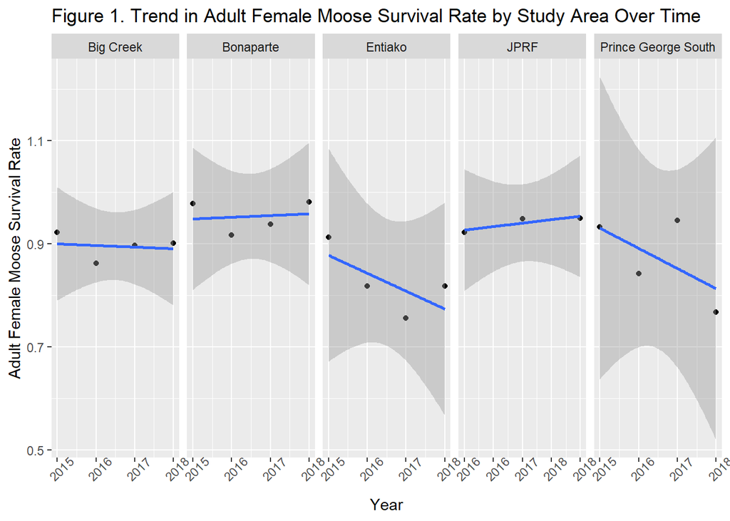

### Relationship Between Cutblocks and Adult Female Moose Survival

```
##                             Value  Std.Error DF   t-value      p-value
## (Intercept)             0.8084954 0.01939982 13 41.675411 3.156242e-15
## prop_cut_8_year_area_ha 1.1927352 0.23933074 13  4.983627 2.500892e-04
```

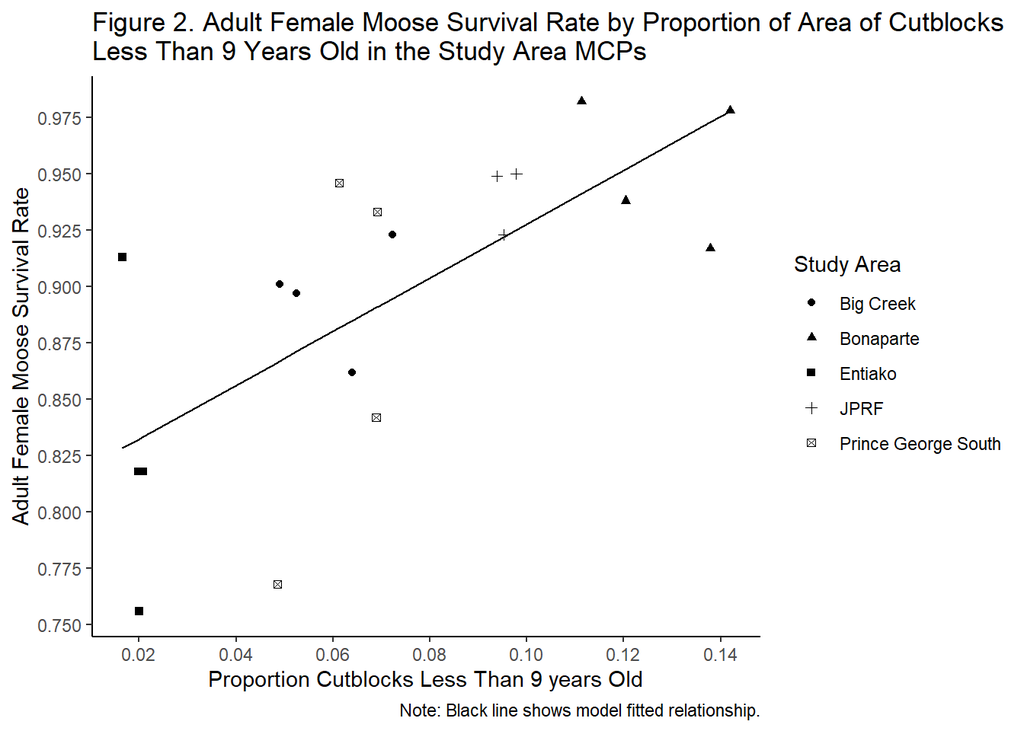

```
##                             Value  Std.Error DF   t-value      p-value
## (Intercept)             0.8896305 0.02045586  8 43.490247 8.619535e-11
## prop_cut_8_year_area_ha 0.8202829 0.31843326  8  2.575996 3.282003e-02
```

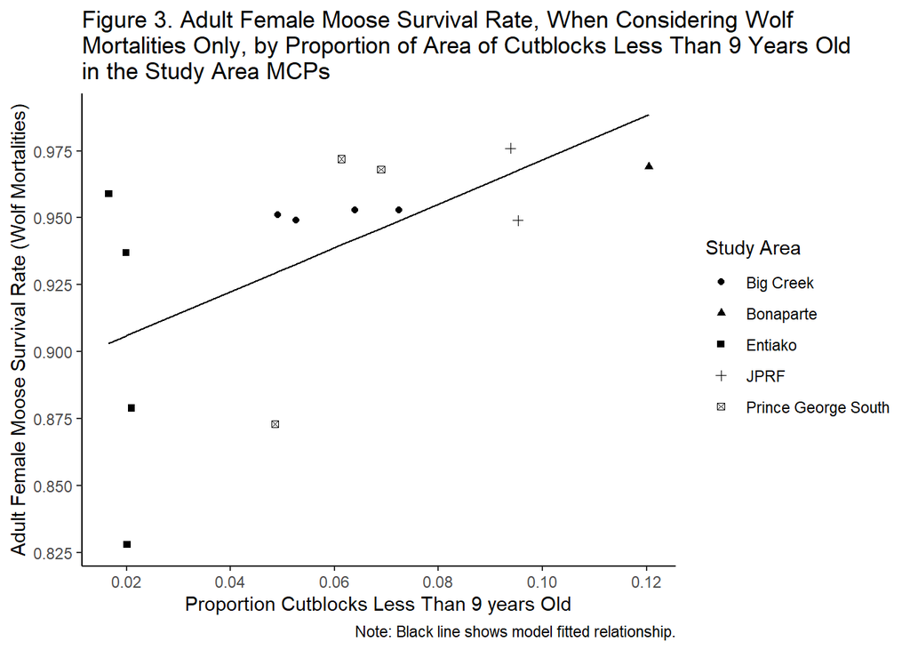

When considering only mortalities from hunting (Fig. 4), the effect of less than 9 year old cutblocks was not statistically significant (*t-value* = 0.59, *p-value* = 0.583), and the effect was close to zero.

```
##                              Value   Std.Error DF    t-value      p-value
## (Intercept)             0.96556055 0.009931779  5 97.2192909 2.182978e-09
## prop_cut_8_year_area_ha 0.06585687 0.112385815  5  0.5859892 5.833354e-01
```

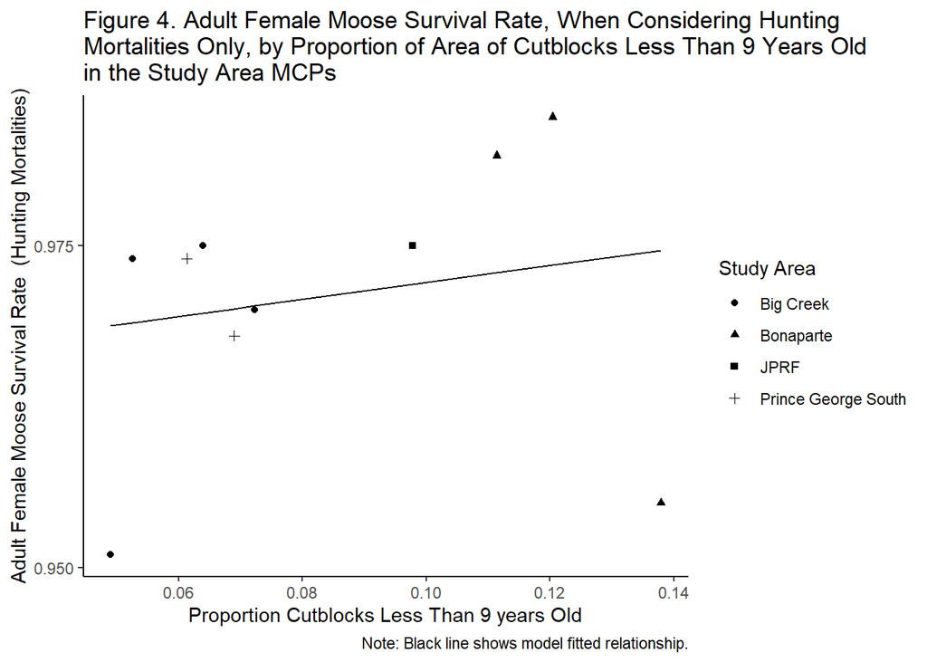

### Relationship Between Mountain Pine Beetle Disturbance and Adult Female Moose Survival

Across the study areas, there was a weak positive relationship between adult female moose survival and the area of less than 9 year mountain pine beetle disturbed stands (Fig. 5). However, the effect was not statistically significant (*t-value* = 0.59, *p-value* = 0.564).

```
##                                 Value  Std.Error DF    t-value
## (Intercept)                 0.8929793 0.02364483 13 37.7663643
## prop_mpb_all_8_year_area_ha 0.1819707 0.30724177 13  0.5922722
##                                  p-value
## (Intercept)                 1.124561e-14
## prop_mpb_all_8_year_area_ha 5.638283e-01
```

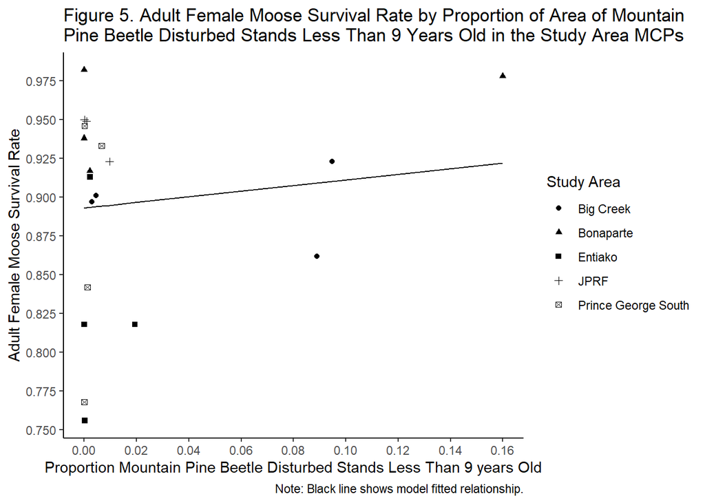

```
##                                  Value  Std.Error DF    t-value
## (Intercept)                 0.93839916 0.01592257  8 58.9351636
## prop_mpb_all_8_year_area_ha 0.09042999 0.42340389  8  0.2135785
##                                  p-value
## (Intercept)                 7.631767e-12
## prop_mpb_all_8_year_area_ha 8.362184e-01
```

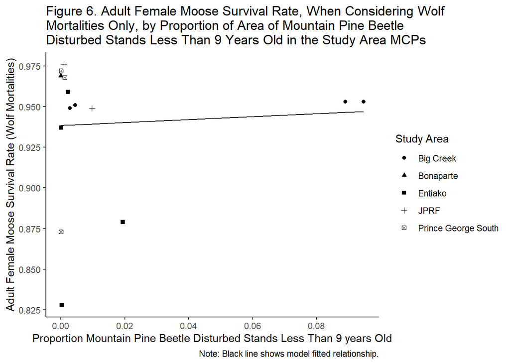

When considering only mortalities from hunting (Fig. 7), the effect of less than 9 year old mountain pine beetle disturbed stands was not statistically significant (*t-value* = 0.13, *p-value* = 0.905), and close to zero.

```
##                                  Value   Std.Error DF     t-value
## (Intercept)                 0.97066314 0.004067867  5 238.6172321
## prop_mpb_all_8_year_area_ha 0.01237632 0.098889130  5   0.1251535
##                                  p-value
## (Intercept)                 2.453088e-11
## prop_mpb_all_8_year_area_ha 9.052783e-01
```

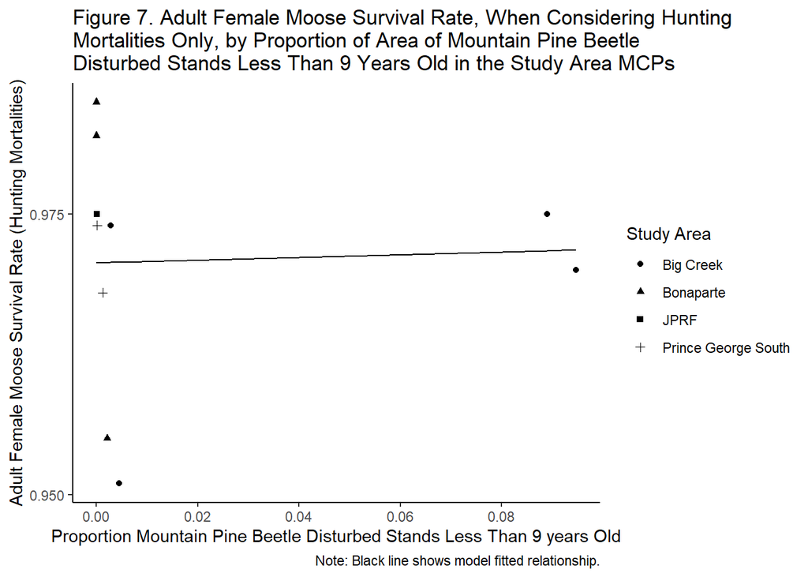

### Cumulative Disturbance

```
##                             Value  Std.Error DF   t-value      p-value
## (Intercept)             0.8476862 0.02396185 13 35.376489 2.610579e-14
## prop_disturb_all_8_year 0.5229974 0.20800132 13  2.514394 2.587641e-02
```

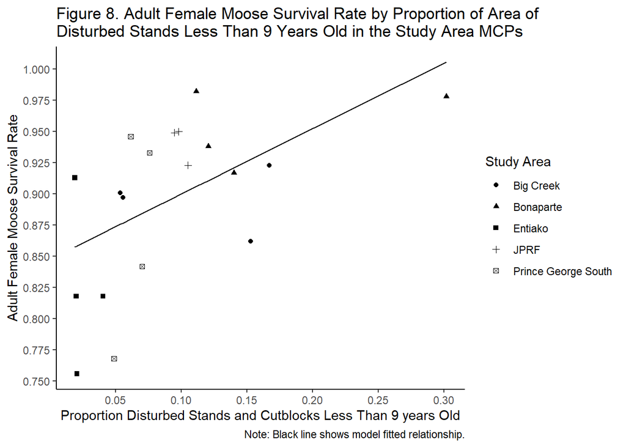

When considering only mortalities from wolves (Fig. 9), the effect of less than 9 year old disturbed stands was not statistically significant (*t-value* = 1.60, *p-value* = 0.147), and each 10% increase in the percent of area of the study area that was less than 9 year old disturbed stands resulted in an approximately 0.04 increase in adult female moose survival.

```
##                             Value  Std.Error DF   t-value      p-value
## (Intercept)             0.9082791 0.02172071  8 41.816273 1.178470e-10
## prop_disturb_all_8_year 0.3975975 0.24772913  8  1.604969 1.471681e-01
```

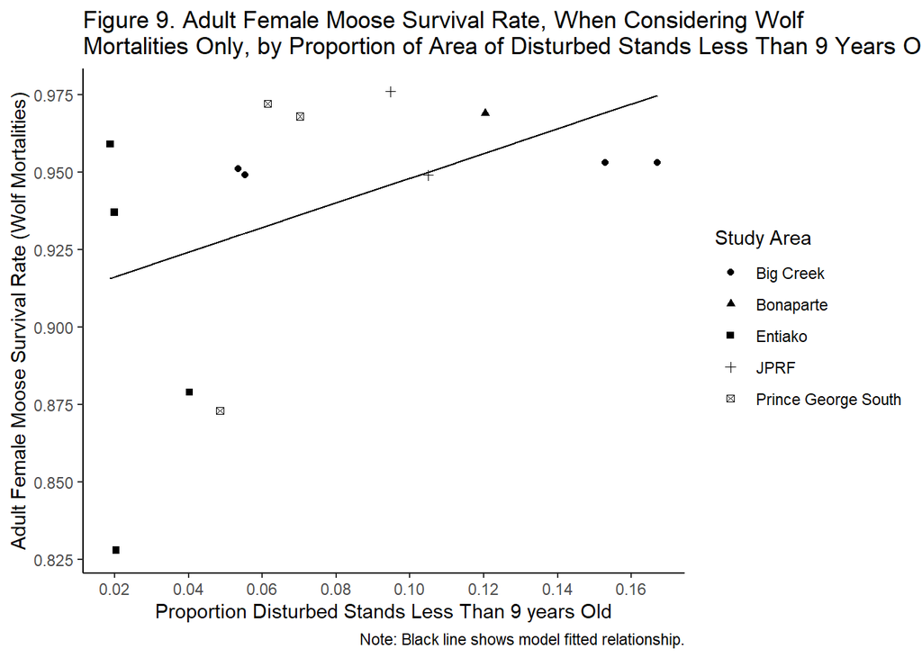

When considering only mortalities from hunting (Fig. 10), the effect of less than 9 year old disturbed stands was not statistically significant (*t-value* = 0.62, *p-value* = 0.560), and close to zero.

```
##                             Value   Std.Error DF     t-value      p-value
## (Intercept)             0.9658101 0.009117012  5 105.9349442 1.421324e-09
## prop_disturb_all_8_year 0.0515018 0.082634742  5   0.6232463 5.604465e-01
```

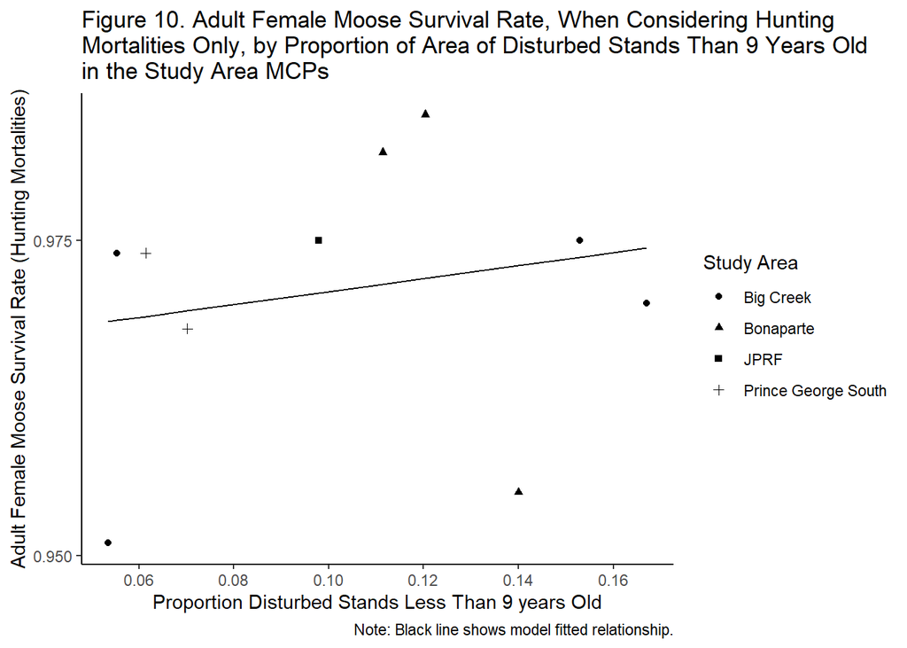

## Preliminary Conclusions

The best fit model included the effect of less than 9 year old cutblocks on adult female moose survival, considering all mortality types. However, hunting mortality did not appear to be related to cutblock disturbance. Recent mountain pine beetle disturbance did not appear to effect adult female moose survival.

The results suggest that recent forest harvest has an overall positive effect on moose survival. At a ‘population scale’, forest harvest may reduce mortality from wolves and ‘other’ types, and did not appear to make moose more vulnerable to human hunters.